# Heatwave-Analyse Kohnen B50 — n1 gegen quantile-gemappte ERA5-Klimatologie

Atmosphärensensor des head03 (Mean-S4), ERA5 1979–2021 an AWS9 kalibriert

Author

Thom Laepple

Published

September 24, 2026

Der Atmosphärensensor **n1** (Node 20) des head03 an B50 gegen die Tagesklimatologie am Kohnen-Gitterpunkt. Heatwave-Kriterium wie im Ursprungsskript (`antwarm26/experiments/plot_n1_vs_era5.R`): Tagesanomalie > 2σ an **mindestens drei aufeinanderfolgenden Tagen**.

Zwei Korrekturen sind für dieses Ergebnis entscheidend — beide wirken in **entgegengesetzte** Richtung, ihr Zusammentreffen ist Zufall:

1. **Sensorkalibrierung.** N20 hat in der Calibration Registry keinen Eintrag und lief früher auf der Beta-Nennkurve, die hier **+1,3 K (−15 °C) bis +4,2 K (−50 °C) zu warm** liest. Seit `decode_combined.R` fällt n1 auf die universelle **Mean-S4-Kurve** zurück.
2. **ERA5-Bias.** ERA5 löst die bodennahe Winterinversion nicht auf: gegen AWS9 ist es im Mittel **+2,3 K zu warm** (Juni +4,6 K, Januar −0,8 K) und hat ein **Varianzdefizit** (SD 8,7 gegen 10,9 K). Eine reine Mittelwertkorrektur würde σ zu klein lassen und zu viele Extremtage erzeugen — deshalb **Quantile-Mapping**.

```r
library(dplyr); library(lubridate); library(readr); library(tidyr)
library(ggplot2); library(patchwork); library(zoo)

ERA5_RDS <- "/Users/tlaepple/data/antwarm26/experiments/era5_legacy_merged.rds"
AWS9_RDA <- "/Users/tlaepple/data/t4m_ms26/data/processed/AWS9_daily.RData"
have <- file.exists(ERA5_RDS) && file.exists(AWS9_RDA)
```

```r
load(AWS9_RDA)                      # -> daily
aws <- daily |> transmute(date = as.Date(day), t = t2m) |> filter(is.finite(t))
era <- readRDS(ERA5_RDS) |>
  transmute(date = as.Date(date), t = as.vector(t2m)) |> filter(is.finite(t))

n1 <- read_csv("./data/decoded_head03_231709_combined.csv", show_col_types = FALSE) |>
  mutate(date = as.Date(time_utc)) |> group_by(date) |>
  summarise(T = mean(n1.ntc1_temp_C, na.rm = TRUE), .groups = "drop") |>
  mutate(doy = pmin(yday(date), 365))
```

## Quantile-Mapping ERA5 → AWS9

Transferfunktion **je Kalendermonat** (der Bias ist stark saisonal) aus 200 Quantilen im Überlappungszeitraum, `rule = 2` an den Rändern (konstanter Offset jenseits des Kalibrierbereichs), angewandt auf den gesamten ERA5-Record.

```r
ov <- inner_join(aws |> rename(ta = t), era |> rename(te = t), by = "date") |>
  mutate(mon = month(date))
probs <- seq(0.005, 0.995, 0.005)
qmap <- lapply(1:12, function(m) {
  d <- ov |> filter(mon == m)
  if (nrow(d) < 60) return(NULL)
  list(q_mod = quantile(d$te, probs, na.rm = TRUE),
       q_obs = quantile(d$ta, probs, na.rm = TRUE))
})
qm_apply <- function(t, mon) {
  out <- rep(NA_real_, length(t))
  for (m in 1:12) {
    k <- which(mon == m); q <- qmap[[m]]
    if (length(k) && !is.null(q)) out[k] <- approx(q$q_mod, q$q_obs, xout = t[k], rule = 2)$y
  }
  out
}
era <- era |> mutate(mon = month(date), t_qm = qm_apply(t, mon))
val <- inner_join(aws |> rename(ta = t), era |> select(date, te = t, tqm = t_qm), by = "date")
```

```r
knitr::kable(tibble(
  Reihe = c("ERA5 roh", "ERA5 quantile-gemappt", "AWS9 (Referenz)"),
  `Bias (K)` = c(mean(val$te - val$ta), mean(val$tqm - val$ta), 0),
  `RMS (K)`  = c(sqrt(mean((val$te-val$ta)^2)), sqrt(mean((val$tqm-val$ta)^2)), 0),
  `SD (K)`   = c(sd(val$te), sd(val$tqm), sd(val$ta))) |>
  mutate(across(where(is.numeric), ~round(.x, 2))),
  caption = sprintf("Validierung im Überlappungszeitraum %s–%s (n = %d Tage). Der verbleibende RMS ist echter Zeitfehler von ERA5 (r = %.3f) und durch kein Mapping korrigierbar.",
                    format(min(val$date), "%Y"), format(max(val$date), "%Y"), nrow(val),
                    cor(val$te, val$ta)))
```

Validierung im Überlappungszeitraum 1997–2016 (n = 3525 Tage). Der verbleibende RMS ist echter Zeitfehler von ERA5 (r = 0.966) und durch kein Mapping korrigierbar.

| Reihe | Bias (K) | RMS (K) | SD (K) |
| --- | --- | --- | --- |
| ERA5 roh | 2.26 | 4.02 | 8.72 |
| ERA5 quantile-gemappt | 0.00 | 2.56 | 10.86 |
| AWS9 (Referenz) | 0.00 | 0.00 | 10.88 |

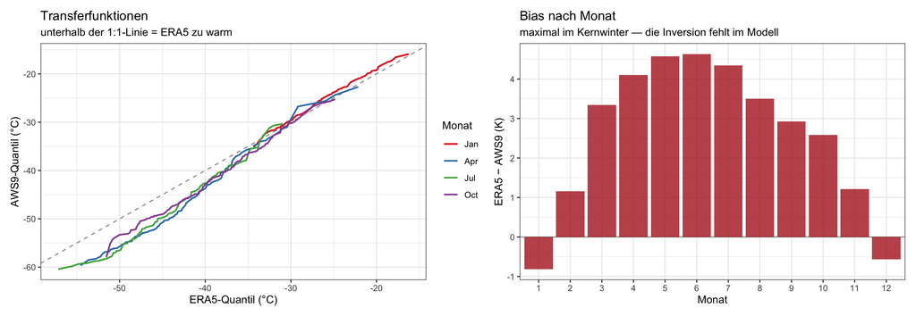

```r
qq <- bind_rows(lapply(c(1, 4, 7, 10), function(m) {
  q <- qmap[[m]]; if (is.null(q)) return(NULL)
  tibble(mod = as.numeric(q$q_mod), obs = as.numeric(q$q_obs),
         Monat = factor(month.abb[m], levels = month.abb)) }))
p_q <- ggplot(qq, aes(mod, obs, colour = Monat)) +
  geom_abline(slope = 1, intercept = 0, linetype = "dashed", colour = "grey60") +
  geom_path(linewidth = 0.8) +
  scale_colour_brewer(palette = "Set1") +
  labs(x = "ERA5-Quantil (°C)", y = "AWS9-Quantil (°C)",
       title = "Transferfunktionen", subtitle = "unterhalb der 1:1-Linie = ERA5 zu warm") +
  theme_bw(11)
bias_mon <- ov |> group_by(mon) |> summarise(b = mean(te - ta), .groups = "drop")
p_b <- ggplot(bias_mon, aes(factor(mon), b)) +
  geom_hline(yintercept = 0, colour = "grey60") +
  geom_col(fill = "firebrick", alpha = 0.8) +
  labs(x = "Monat", y = "ERA5 − AWS9 (K)", title = "Bias nach Monat",
       subtitle = "maximal im Kernwinter — die Inversion fehlt im Modell") +
  theme_bw(11)
p_q + p_b
```

## Klimatologien und Anomalien

```r
clim_of <- function(df, col, y0, y1) {
  cr <- df |> filter(year(date) >= y0, year(date) <= y1) |>
    mutate(doy = pmin(yday(date), 365)) |> group_by(doy) |>
    summarise(m = mean(.data[[col]], na.rm = TRUE), s = sd(.data[[col]], na.rm = TRUE),
              .groups = "drop") |> arrange(doy)
  np <- 15
  bind_rows(cr |> slice_tail(n = np) |> mutate(doy = doy - 365), cr,
            cr |> slice_head(n = np) |> mutate(doy = doy + 365)) |>
    mutate(clim_mean = as.vector(rollmean(m, 31, fill = NA, align = "center")),
           clim_sd   = as.vector(rollmean(s, 31, fill = NA, align = "center"))) |>
    filter(doy >= 1, doy <= 365) |> select(doy, clim_mean, clim_sd)
}
c_qm  <- clim_of(era, "t_qm", 1979, 2021)     # Hauptvariante
c_raw <- clim_of(era, "t",    1979, 2021)
c_aws <- clim_of(aws |> mutate(tt = t), "tt", 1998, 2016)

anom <- function(cl) { j <- left_join(n1, cl, by = "doy"); (j$T - j$clim_mean)/j$clim_sd }
n1 <- n1 |> mutate(a_qm = anom(c_qm), a_raw = anom(c_raw), a_aws = anom(c_aws))
hw_flag <- function(a) { e <- !is.na(a) & a > 2; r <- rle(e); e & rep(r$lengths, r$lengths) >= 3 }
n1 <- n1 |> mutate(hw = hw_flag(a_qm))
```

```r
sens <- tibble(Klimatologie = c("**ERA5 quantile-gemappt** (Hauptvariante)",
                                "ERA5 roh", "AWS9 direkt (1998–2016)"),
               a = list(n1$a_qm, n1$a_raw, n1$a_aws)) |>
  rowwise() |>
  mutate(`Tage > 2σ` = sum(a > 2, na.rm = TRUE),
         `Heatwave-Tage` = sum(hw_flag(a), na.rm = TRUE),
         `max σ` = round(max(a, na.rm = TRUE), 2),
         `Mittel σ` = round(mean(a, na.rm = TRUE), 2)) |>
  ungroup() |> select(-a)
knitr::kable(sens, caption = "Sensitivität gegenüber der Klimatologie.")
```

Sensitivität gegenüber der Klimatologie.

| Klimatologie | Tage > 2σ | Heatwave-Tage | max σ | Mittel σ |
| --- | --- | --- | --- | --- |
| **ERA5 quantile-gemappt** (Hauptvariante) | 8 | 3 | 2.92 | -0.06 |
| ERA5 roh | 3 | 0 | 2.68 | -0.66 |
| AWS9 direkt (1998–2016) | 4 | 0 | 2.88 | -0.21 |

```r
nhw <- sum(n1$hw, na.rm = TRUE)
if (nhw > 0) {
  ev <- n1 |> filter(hw)
  cat(sprintf("**Heatwave-Ereignis: %s bis %s** (%d Tage, %+.2f bis %+.2fσ, %.1f bis %.1f °C). Die Saison liegt im Mittel bei **%+.2fσ**, also klimatologisch normal.\n",
              format(min(ev$date), "%d.%m."), format(max(ev$date), "%d.%m.%Y"), nrow(ev),
              min(ev$a_qm), max(ev$a_qm), min(ev$T), max(ev$T), mean(n1$a_qm, na.rm = TRUE)))
} else {
  cat(sprintf("**Kein Heatwave-Ereignis** (kein Lauf von ≥ 3 Tagen über 2σ); Saisonmittel %+.2fσ.\n",
              mean(n1$a_qm, na.rm = TRUE)))
}
```

**Heatwave-Ereignis: 30.06. bis 02.07.2026** (3 Tage, +2.10 bis +2.92σ, -34.9 bis -28.5 °C). Die Saison liegt im Mittel bei **-0.06σ**, also klimatologisch normal.

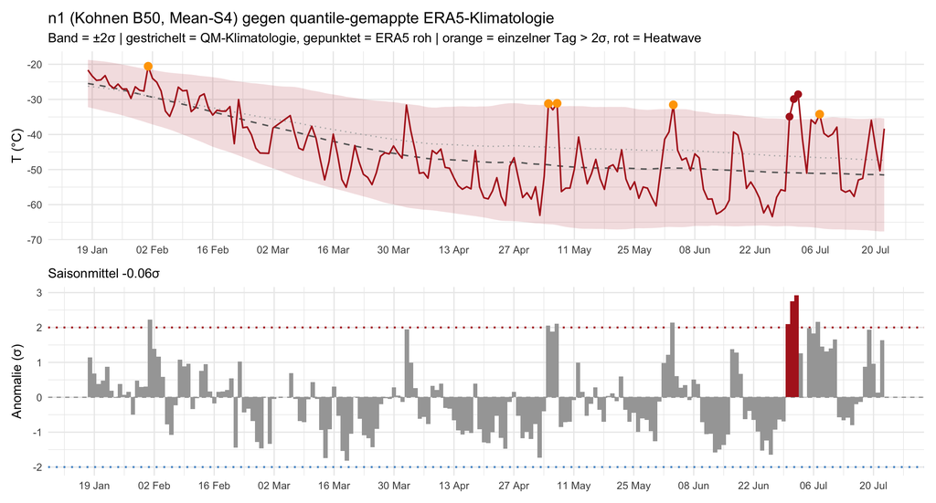

```r
rib <- c_qm |> filter(doy >= min(n1$doy), doy <= max(n1$doy)) |>
  mutate(date = as.Date(format(min(n1$date), "%Y-01-01")) + doy - 1)
raw_rib <- c_raw |> filter(doy >= min(n1$doy), doy <= max(n1$doy)) |>
  mutate(date = as.Date(format(min(n1$date), "%Y-01-01")) + doy - 1)

p1 <- ggplot(n1, aes(date, T)) +
  geom_ribbon(data = rib, aes(x = date, ymin = clim_mean - 2*clim_sd,
                              ymax = clim_mean + 2*clim_sd),
              fill = "firebrick", alpha = 0.15, inherit.aes = FALSE) +
  geom_line(data = rib, aes(date, clim_mean), colour = "grey40",
            linetype = "dashed", linewidth = 0.7, inherit.aes = FALSE) +
  geom_line(data = raw_rib, aes(date, clim_mean), colour = "grey70",
            linetype = "dotted", linewidth = 0.6, inherit.aes = FALSE) +
  geom_line(colour = "firebrick", linewidth = 0.75) +
  geom_point(data = filter(n1, a_qm > 2 & !hw), colour = "orange", size = 2.5,
             shape = 21, stroke = 1.2, fill = "orange") +
  geom_point(data = filter(n1, hw), colour = "firebrick", size = 3) +
  scale_x_date(date_breaks = "2 weeks", date_labels = "%d %b") +
  labs(x = NULL, y = "T (°C)",
       title = "n1 (Kohnen B50, Mean-S4) gegen quantile-gemappte ERA5-Klimatologie",
       subtitle = "Band = ±2σ | gestrichelt = QM-Klimatologie, gepunktet = ERA5 roh | orange = einzelner Tag > 2σ, rot = Heatwave") +
  theme_minimal(base_size = 13)

p2 <- ggplot(n1, aes(date, a_qm)) +
  geom_hline(yintercept = 0, colour = "grey60", linetype = "dashed") +
  geom_hline(yintercept = c(-2, 2), colour = c("steelblue3", "firebrick"),
             linetype = "dotted", linewidth = 0.9) +
  geom_col(aes(fill = hw), show.legend = FALSE, width = 1) +
  scale_fill_manual(values = c(`FALSE` = "grey65", `TRUE` = "firebrick")) +
  scale_x_date(date_breaks = "2 weeks", date_labels = "%d %b") +
  labs(x = NULL, y = "Anomalie (σ)",
       subtitle = sprintf("Saisonmittel %+.2fσ", mean(n1$a_qm, na.rm = TRUE))) +
  theme_minimal(base_size = 13)

p1 / p2
```

```r
knitr::kable(n1 |> arrange(desc(a_qm)) |> head(8) |>
  transmute(Datum = format(date, "%d.%m.%Y"), `n1 (°C)` = round(T, 1),
            `σ (QM)` = round(a_qm, 2), `σ (ERA5 roh)` = round(a_raw, 2),
            `σ (AWS9)` = round(a_aws, 2)),
  caption = "Wärmste Tage der Reihe unter den drei Klimatologien.")
```

Wärmste Tage der Reihe unter den drei Klimatologien.

| Datum | n1 (°C) | σ (QM) | σ (ERA5 roh) | σ (AWS9) |
| --- | --- | --- | --- | --- |
| 02.07.2026 | -28.5 | 2.92 | 2.68 | 2.88 |
| 01.07.2026 | -29.9 | 2.75 | 2.48 | 2.67 |
| 01.02.2026 | -20.6 | 2.23 | 2.41 | 2.26 |
| 07.07.2026 | -34.2 | 2.17 | 1.82 | 2.02 |
| 03.06.2026 | -31.5 | 2.14 | 1.86 | 1.58 |
| 07.05.2026 | -31.1 | 2.11 | 1.86 | 1.53 |
| 30.06.2026 | -34.9 | 2.10 | 1.71 | 1.95 |
| 05.05.2026 | -31.2 | 2.06 | 1.82 | 1.45 |

## Wie ungewöhnlich ist das?

Einordnung als stationäres Wiederkehrereignis: dieselbe Klimatologie und dasselbe Kriterium, angewandt auf die **quantile-gemappte ERA5-Reihe 1940–2026** (87 Jahre). Damit ist der 2026er Wert direkt in die historische Verteilung einsortierbar.

```r
era_a <- era |> mutate(doy = pmin(yday(date), 365)) |>
  left_join(c_qm, by = "doy") |>
  mutate(a = (t_qm - clim_mean)/clim_sd, year = year(date)) |> arrange(date)
era_a$a3 <- rollmean(era_a$a, 3, fill = NA, align = "center")

find_runs <- function(df) {
  x <- !is.na(df$a) & df$a > 2; r <- rle(x)
  i <- which(r$values & r$lengths >= 3)
  if (!length(i)) return(tibble())
  ends <- cumsum(r$lengths); starts <- ends - r$lengths + 1
  tibble(start = df$date[starts[i]], end = df$date[ends[i]], len = r$lengths[i],
         maxa  = vapply(i, function(k) max(df$a[starts[k]:ends[k]]), 0),
         mean3 = vapply(i, function(k) mean(df$a[starts[k]:ends[k]]), 0))
}
ev_hist <- find_runs(era_a)
n_years <- length(unique(era_a$year))

obs <- n1 |> filter(hw)
obs_max <- max(obs$a_qm); obs_m3 <- mean(obs$a_qm)

rp <- tibble(Schwelle = c(2.0, 2.5, round(obs_m3, 2), 3.0, 3.5)) |> rowwise() |>
  mutate(`Ereignisse (Jahr)` = sum(ev_hist$mean3 >= Schwelle),
         `alle x Jahre` = round(n_years/max(`Ereignisse (Jahr)`, 1), 1),
         `Ereignisse (Apr–Sep)` = sum(ev_hist$mean3 >= Schwelle & month(ev_hist$start) %in% 4:9),
         `alle x Jahre (Apr–Sep)` = round(n_years/max(`Ereignisse (Apr–Sep)`, 1), 1)) |> ungroup()
knitr::kable(rp, caption = sprintf(
  "Wiederkehrzeit nach 3-Tage-Mittel der Anomalie, %d–%d (%d Jahre). Unser Ereignis liegt bei %.2f σ.",
  min(era_a$year), max(era_a$year), n_years, obs_m3))
```

Wiederkehrzeit nach 3-Tage-Mittel der Anomalie, 1940–2026 (87 Jahre). Unser Ereignis liegt bei 2.59 σ.

| Schwelle | Ereignisse (Jahr) | alle x Jahre | Ereignisse (Apr–Sep) | alle x Jahre (Apr–Sep) |
| --- | --- | --- | --- | --- |
| 2.00 | 160 | 0.5 | 94 | 0.9 |
| 2.50 | 71 | 1.2 | 43 | 2.0 |
| 2.59 | 41 | 2.1 | 24 | 3.6 |
| 3.00 | 3 | 29.0 | 2 | 43.5 |
| 3.50 | 0 | 87.0 | 0 | 87.0 |

```r
n_ge <- sum(ev_hist$mean3 >= obs_m3)
a_all <- era_a$a[is.finite(era_a$a)]
cat(sprintf("- **Unser Ereignis (%.2f σ im 3-Tage-Mittel, Spitze %.2f σ) ist ein ~%.0f-Jahres-Ereignis** (im Winterhalbjahr ~%.0f Jahre) — kein Ausreißer der Klimatologie.
",
            obs_m3, obs_max, n_years/max(n_ge, 1),
            n_years/max(sum(ev_hist$mean3 >= obs_m3 & month(ev_hist$start) %in% 4:9), 1)))
```

- **Unser Ereignis (2.59 σ im 3-Tage-Mittel, Spitze 2.92 σ) ist ein ~2-Jahres-Ereignis** (im Winterhalbjahr ~4 Jahre) — kein Ausreißer der Klimatologie.

```r
cat(sprintf("- **Das 2σ-Kriterium ist an diesem Standort schwach:** %d Ereignisse in %d Jahren, also fast zwei pro Jahr. Grund ist die Verteilung: %.2f %% aller Tage liegen über 2σ (Gauß-Erwartung 2,28 %%), die Schiefe beträgt **%+.2f**, und die Lag-1-Autokorrelation **%.2f** — bei so viel Persistenz ist „drei Tage in Folge\" kaum eine zusätzliche Hürde. Ab **3σ** wird es selten (%d Ereignisse in %d Jahren).
",
            nrow(ev_hist), n_years, 100*mean(a_all > 2),
            mean((a_all-mean(a_all))^3)/sd(a_all)^3,
            cor(a_all[-1], a_all[-length(a_all)]),
            sum(ev_hist$mean3 >= 3), n_years))
```

- **Das 2σ-Kriterium ist an diesem Standort schwach:** 160 Ereignisse in 87 Jahren, also fast zwei pro Jahr. Grund ist die Verteilung: 4.17 % aller Tage liegen über 2σ (Gauß-Erwartung 2,28 %), die Schiefe beträgt **+0.67**, und die Lag-1-Autokorrelation **0.82** — bei so viel Persistenz ist „drei Tage in Folge” kaum eine zusätzliche Hürde. Ab **3σ** wird es selten (3 Ereignisse in 87 Jahren).

```r
yr_tab <- era_a |> filter(year >= 2013, year <= 2025) |> group_by(year) |>
  summarise(`max 3-Tage-Mittel (σ)` = round(max(a3, na.rm = TRUE), 2),
            `Tage > 2σ` = sum(a > 2, na.rm = TRUE),
            `Mehrtagesereignisse` = sum(year(ev_hist$start) == first(year)),
            .groups = "drop") |> rename(Jahr = year)
knitr::kable(yr_tab, caption = "Jahresvergleich aus der QM-ERA5-Reihe (2026 fehlt, da der ERA5-Record am 22.01.2026 endet).")
```

Jahresvergleich aus der QM-ERA5-Reihe (2026 fehlt, da der ERA5-Record am 22.01.2026 endet).

| Jahr | max 3-Tage-Mittel (σ) | Tage > 2σ | Mehrtagesereignisse |
| --- | --- | --- | --- |
| 2013 | 2.69 | 25 | 5 |
| 2014 | 2.81 | 13 | 1 |
| 2015 | 2.50 | 16 | 2 |
| 2016 | 3.04 | 14 | 3 |
| 2017 | 2.65 | 17 | 3 |
| 2018 | 2.88 | 28 | 3 |
| 2019 | 2.49 | 15 | 1 |
| 2020 | 2.86 | 22 | 2 |
| 2021 | 2.59 | 25 | 2 |
| 2022 | 2.79 | 12 | 1 |
| 2023 | 3.21 | 44 | 6 |
| 2024 | 2.76 | 43 | 5 |
| 2025 | 2.72 | 23 | 4 |

```r
knitr::kable(ev_hist |> arrange(desc(mean3)) |> head(8) |>
  transmute(Beginn = format(start, "%d.%m.%Y"), Ende = format(end, "%d.%m.%Y"),
            Tage = len, `max σ` = round(maxa, 2), `3-Tage-Mittel σ` = round(mean3, 2)),
  caption = "Stärkste Ereignisse des Records.")
```

Stärkste Ereignisse des Records.

| Beginn | Ende | Tage | max σ | 3-Tage-Mittel σ |
| --- | --- | --- | --- | --- |
| 25.05.2009 | 27.05.2009 | 3 | 3.33 | 3.20 |
| 19.04.2016 | 21.04.2016 | 3 | 3.18 | 3.04 |
| 15.11.2023 | 20.11.2023 | 6 | 3.25 | 3.01 |
| 04.11.2007 | 14.11.2007 | 11 | 3.44 | 2.96 |
| 23.02.2003 | 01.03.2003 | 7 | 3.36 | 2.91 |
| 09.04.1947 | 12.04.1947 | 4 | 3.17 | 2.85 |
| 14.06.1969 | 16.06.1969 | 3 | 2.96 | 2.83 |
| 17.01.1981 | 24.01.1981 | 8 | 2.99 | 2.82 |

```r
e24 <- era_a |> filter(year == 2024)
ev24 <- ev_hist |> filter(year(start) == 2024)
cat(sprintf("**Vergleich 2024:** max Tagesanomalie **%+.2f σ** (%s), max 3-Tage-Mittel **%+.2f σ**, **%d Tage** über 2σ und **%d** Mehrtagesereignisse — darunter eines über **%d Tage** (%s–%s), also in derselben Jahreszeit wie unseres, aber dreimal so lang. 2024 (und 2023 mit %d Tagen über 2σ) waren damit deutlich anomaler als 2026.
",
  max(e24$a, na.rm = TRUE), format(e24$date[which.max(e24$a)], "%d.%m."),
  max(e24$a3, na.rm = TRUE), sum(e24$a > 2, na.rm = TRUE), nrow(ev24),
  max(ev24$len), format(ev24$start[which.max(ev24$len)], "%d.%m."),
  format(ev24$end[which.max(ev24$len)], "%d.%m."),
  sum(era_a$a[era_a$year == 2023] > 2, na.rm = TRUE)))
```

**Vergleich 2024:** max Tagesanomalie **+2.89 σ** (22.02.), max 3-Tage-Mittel **+2.76 σ**, **43 Tage** über 2σ und **5** Mehrtagesereignisse — darunter eines über **9 Tage** (25.07.–02.08.), also in derselben Jahreszeit wie unseres, aber dreimal so lang. 2024 (und 2023 mit 44 Tagen über 2σ) waren damit deutlich anomaler als 2026.

## Vorbehalte

```r
cat("**Eingangsdaten fehlen** — ERA5 (`", ERA5_RDS, "`) oder AWS9 (`", AWS9_RDA,
    "`) nicht gefunden; Analyse übersprungen.\n", sep = "")
```